# ESM 204 Assignment 4

Naomi Raal, Virgina Pan, and Cam Audras

5/22/2022

### **1. Damages vs. Change in Temperature**

Using damages.csv, estimate a quadratic damage function relating the dollar value of damages to the change in global mean temperature. Estimate a model with a zero intercept because damages by construction must equal zero when there is no climate change. Plot your estimated damage function, overlaid with a scatterplot of the underlying data.

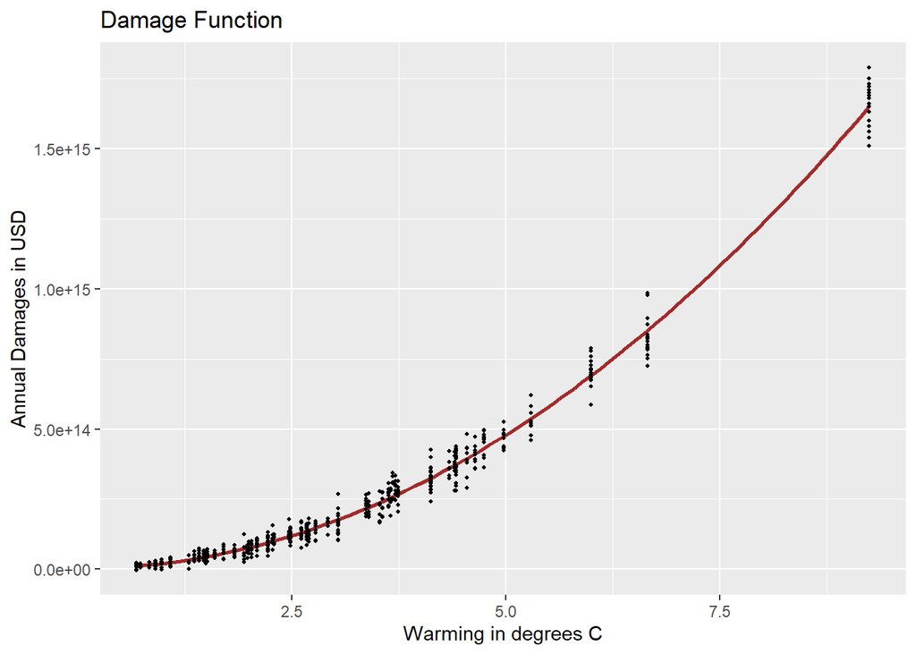

### **2. Predicted Damages per Year**

Use warming.csv and your estimated damage function to predict damages in each year under the baseline climate and the pulse scenario. Make four plots: (1) damages over time without the pulse, (2) damages over time with the pulse, (3) the difference in damages over time that arises from the pulse, and (4) the difference in damages over time from the pulse per ton of CO2 (you can assume that each ton of the pulse causes the same amount of damage).

1. damages in each year under baseline climate scenario

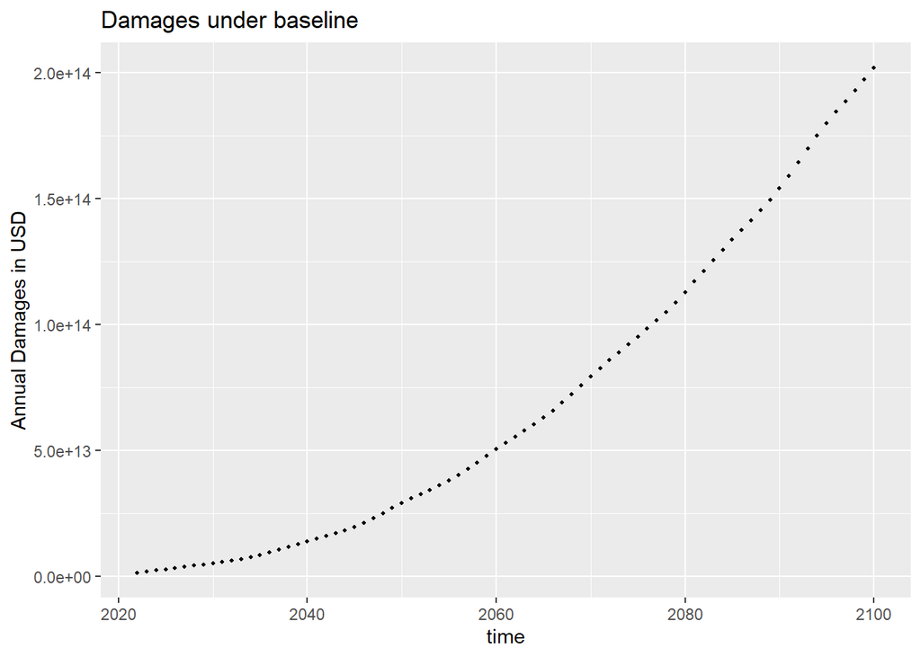

2. damages in each year under baseline + pulse climate scenario

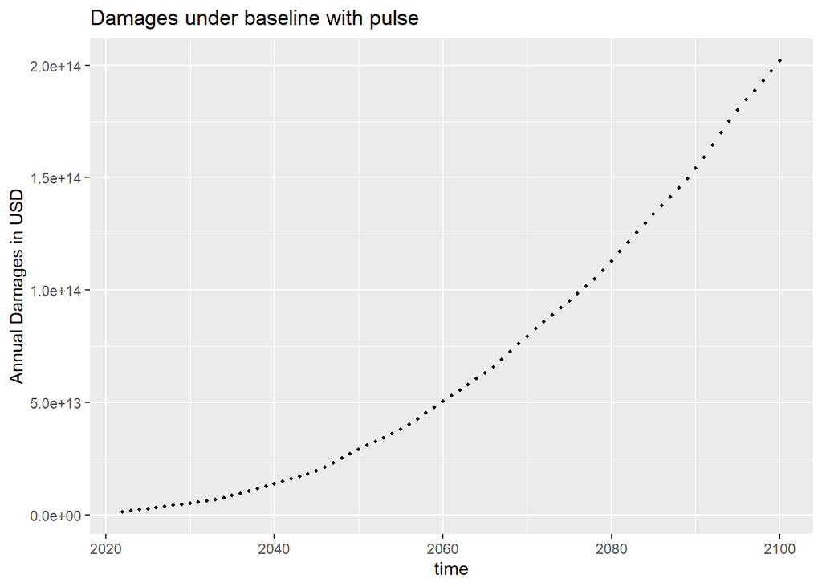

3. damages in each year under pulse alone climate scenario

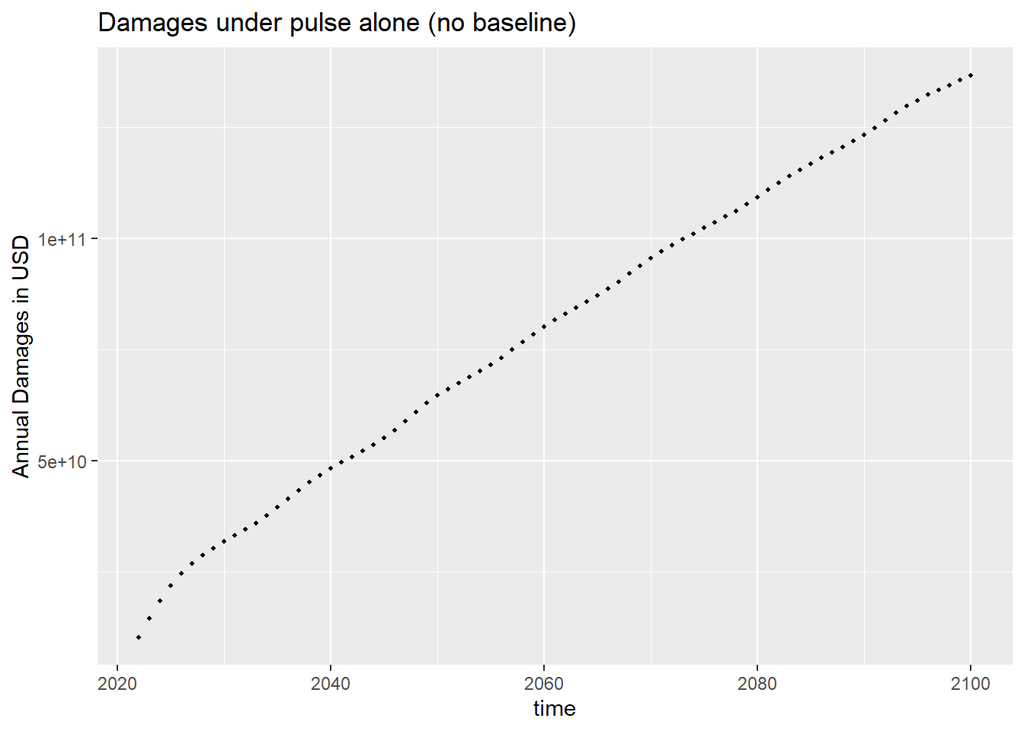

4. difference in damages over time per ton of CO2

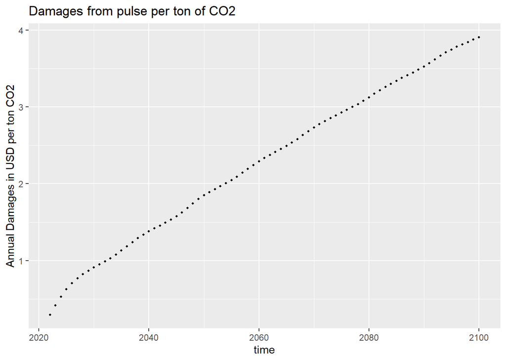

### **3. Investigating the Relationship between Discount Rate and SCC**

The SCC is the present discounted value of the stream of future damages caused by one additional ton of CO2. The Obama Administration used a discount rate of 3% to discount damages. Recently, New York State used a discount rate of 2%. Calculate and make a plot of the SCC (y-axis) against the discount rate (x-axis) for a reasonable range of discount rates. Explain the intuition for how the discount rate affects the SCC.

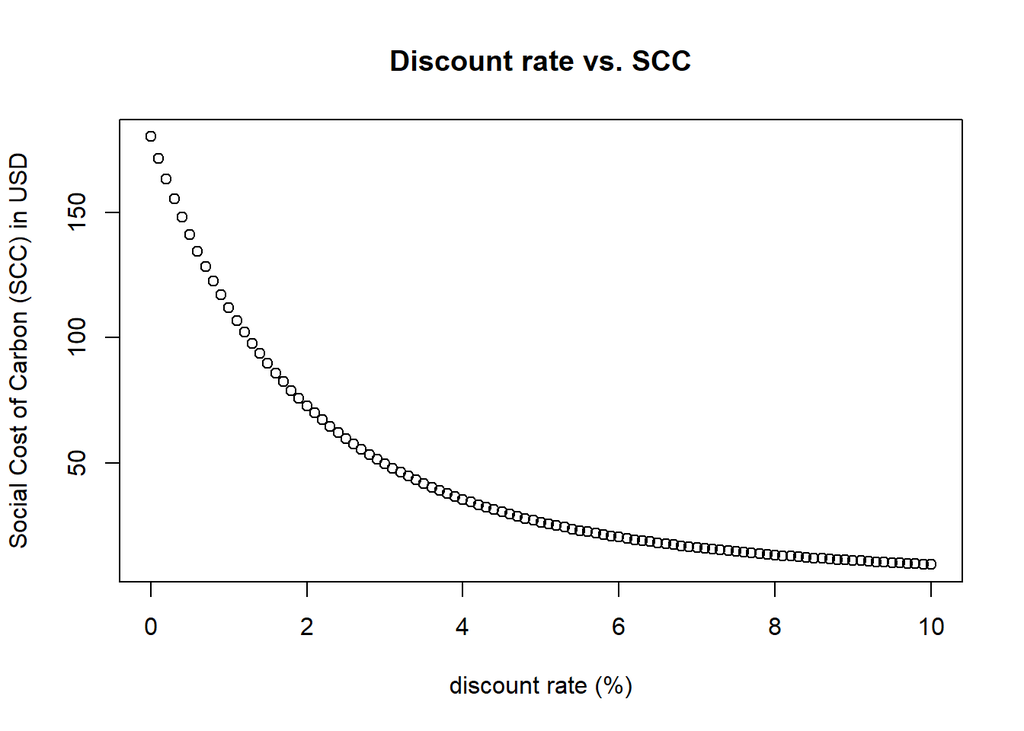

This plot of discount rate (%) vs. the Social Cost of Carbon (SCC) is consistent with our expectations. We expect the SCC to decrease as the discount rate increases. This is because at a higher discount rate, the value of the future damages is less. Broadly, this means people care less about the future generations than the care about today. Therefore, it is more valuable to emit carbon today and the SCC is low when the discount rate is high.

### **4. Using the Ramsey Rule to find SCC**

The National Academies of Sciences, Engineering, and Medicine advised the government in a 2017 report to use the Ramsey Rule when discounting within the SCC calculation:

r = ρ + ηg

Using ρ = 0.001, η = 2, and g = 0.01

What is the SCC? Locate this point on your graph from above.

SCC calculation Under the Ramsey Rule:

r = ρ + ηg

Using ρ = 0.001, η = 2, and g = 0.01:

r = 0.021

SCC = $69.89

Plot with Ramsey discount rate in blue and SCC under Ramsey rule in red.

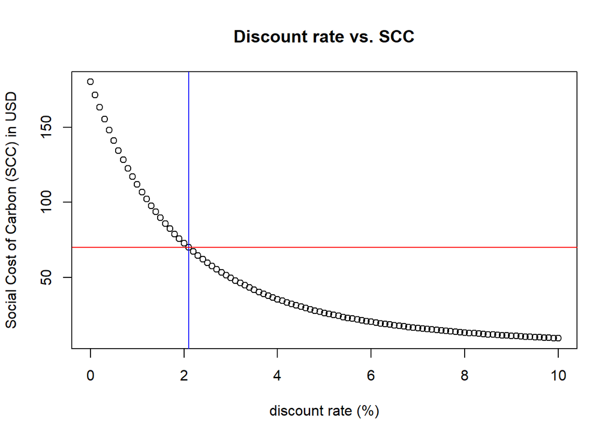

### **5. Comparing Potential Policy Outcomes**

Now suppose there are two possible climate policies that can be pursued. Policy A is business as usual and Policy B is to take immediate and strong action on climate change. Use these facts:

If you undertake Policy A there are two possible outcomes. Either warming will occur as in the “baseline” (i.e. “no-pulse”) dataset above (this happens with probability 0.5) or warming each year will be 1.5 times that in the “baseline” dataset (with probability 0.5).

Under Policy B, warming will continue until 2050 as in the “baseline” dataset, and then will stabilize at 1.29 degrees and stay that way forever.

Society is risk neutral

Use a discount rate of 2%

What is the expected present value of damages up to 2100 under Policy A? What is the expected present value of damages up to 2100 under Policy B? Suppose undertaking Policy A costs zero and undertaking Policy B costs X. The total cost of a policy is the implementation cost plus expected damages. Make a plot of total cost of Policy A and total cost of Policy B against X. Suppose Congress wants to undertake the policy with the lower total cost. Use your graph to advise Congress.

The expected present value of damages up to 2100 under Policy A: $ 2.9639662^{15}

The expected present value of damages up to 2100 under Policy B: $ 7.7124635^{14}

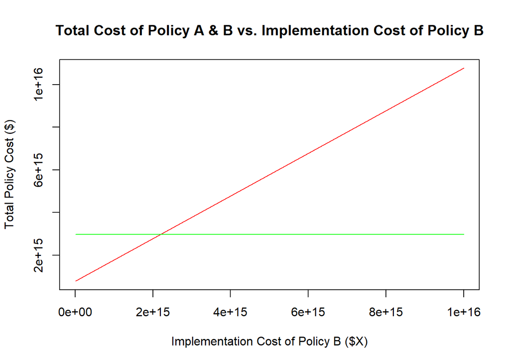

Plot with implementation cost of policy B ($X) on the x-axis and total policy cost (implementation cost + expected damages cost) of policy A (green line) and policy B (red line) on the y-axis

Suppose Congress wants to undertake the policy with the lower total cost. Use your graph to advise Congress.

Congress should choose policy B if policy B’s implementation cost is less than $ 2.1927199^{15} (to the left of where the total cost lines intersect).

Congress should and choose policy A if policy B’s implementation cost is greater than $ 2.1927199^{15} (to the right of where the total cost lines intersect).

Congress would be would be open to choosing either policy if policy B’s implementation cost is exactly $ 2.1927199^{15} (exactly at the intersection of policy costs).

### **6. Effect of a Risk Averse Society on Advice**

Now suppose that society is risk averse. How do you think this would change your advice to Congress?

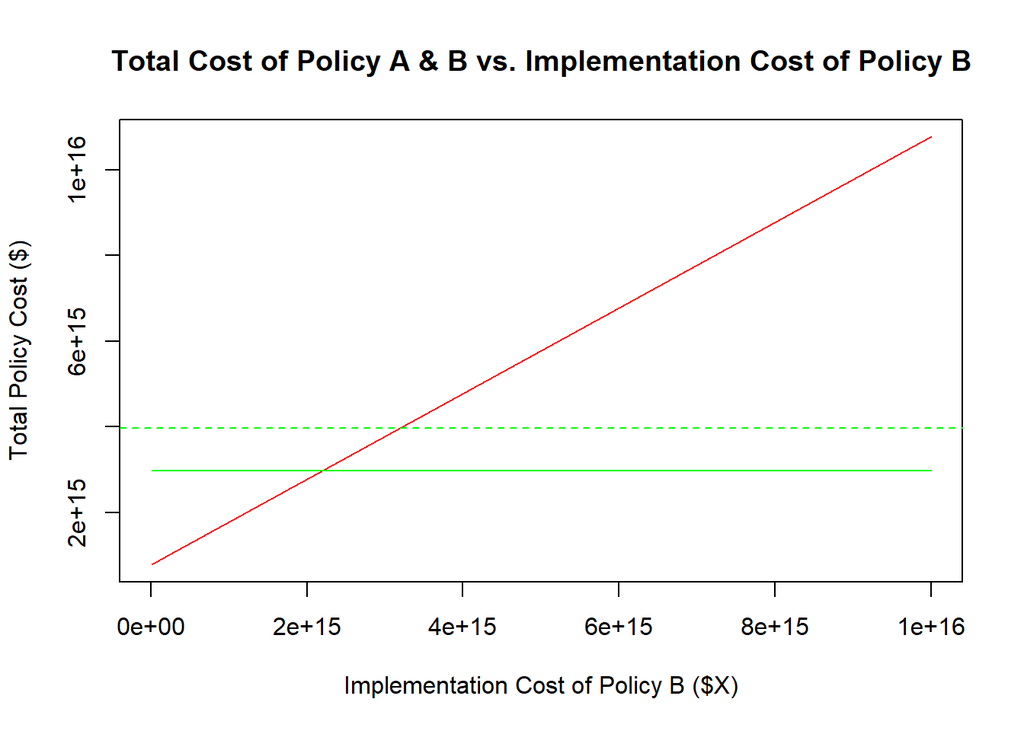

Plot with implementation cost of policy B ($X) on the x-axis and total policy cost (implementation cost + expected damages cost) of policy A (green solid line), policy A in a risk averse society (dotted green line) and policy B (red line) on the y-axis.

If society is risk averse, than the expected costs of policy A would be greater. As such, the cost of policy A would shift up in the graph above (example: green dotted line). This would make policy B more attractive, up to a certain implementation cost (which would be higher than $ 2.1927199^{15}. Basically, Congress is more likely to choose Policy B in a risk averse society.